# **Curso**

## *6.3 Manipulando vetores*

Quando criamos um vetor, há situações em que precisamos acessar as posições, acessar os valores por uma condição lógica ou precisamos acrescentar valores. Para essas situações, podemos acessar posições utilizando os colchetes `vetor[1]`. Nessa ocasião, o valor que estará dentro dos colchetes se refere à posição do valor.  
Caso queremos atribuir uma condição lógica, podemos utilizar os operadores lógicos. `vetor[vetor > 0]`, nesse exemplo percebemos que estamos extraindo todos os valores do vetor que são maiores que 0.

Para tornar mais didático, imagine um vetor = c(-1, 2, 4, -10). Observe que os valores menores ou iguais a 0 são `-1` e `-10`. Se eu rodar o script vetor > 0, ele retornará: FALSE, TRUE, TRUE, FALSE. Perceba que, ele retorna um valor **booleano**.

Portanto, na condição `vetor[vetor > 0]`, estamos dizendo para o script buscar as posições que são verdadeiras `TRUE`. Basicamente: vetor[c(FALSE, TRUE, TRUE, FALSE)]. Diante disso, retornará no console as posições *2* e *3*, ou seja, os valores 2 e 4.

Quando queremos acrescentar um valor, podemos atribuir uma posição a mais do tamanho do vetor. Imagine que um vetor tenha tamanho 3. Caso quiséssemos acrescentar a posição 4, basta rodar: `vetor[4] = 1`. Nesse caso, estamos acrescentando o número 1 à posição 4. O mesmo vale para alterar valores, como por exemplo: vetor[3] = 50. Nesse caso, a posição 3 está sendo alterada para o valor 50. Podemos também colocar valores negativos, indicando a impressão de todo o vetor menos a posição indicada.

```r
vetor1[1] #Primeira posição do meu vetor
```

```
## [1] 1
```

```r
vetor1[vetor1%%2 == 1] #Atribuição lógica
```

```
## [1] 1 5
```

```r
vetor1[4] = 10 #Acrescentando valores ao vetor

vetor1[-1] #Retorna todo o vetor, menos a primeira posição
```

```
## [1]  5  6 10
```

## *6.4 Operações com vetores*

Ao criar vetores, podemos necessitar de realizar operações com os mesmos.  
Para realizar a soma de todos os valores de um vetor, basta utilizar a função `sum`. Entretanto, caso você queira realizar a soma de cada elemento entre dois vetores, podemos apenas somá-los: `vetor1 + vetor2`. Para multiplicar um vetor por um *escalar*, podemos apenas multiplicá-lo `vetor1 * 3`. Podemos concatenar vetores, apenas com a função `c()`. Caso queira conhecer mais sobre as operações, recomendo este documento da [Ecologia da USP](http://ecologia.ib.usp.br/bie5782/doku.php?id=bie5782:03_apostila:03-funcoes).

```r
vetor1 = c(1,2)
vetor2 = c(10,20)
sum(vetor1) #Somando todos os elementos do vetor1
```

```
## [1] 3
```

```r
vetor1 + vetor2 #Somando vetor com vetor
```

```
## [1] 11 22
```

```r
vetor1*2 #Multiplicando um vetor por um escalar
```

```
## [1] 2 4
```

```r
concatenar = c(vetor1,vetor2) #vetor dentro de vetor
concatenar
```

```
## [1]  1  2 10 20
```

## *6.5 A criação de sequências*

Por vezes, precisamos criar sequências. Um jeito bem simples de criar uma sequência é utilizando a notação `:`, onde antes colocamos o valor inicial e depois o valor final da nossa sequência. Essa notação gera uma sequência linear de 1 em 1.  
Podemos, também, utilizar a função `rep()` para gerar a repetição de um valor por uma determinada unidade. Ademais, podemos usar a função `seq()` para gerar uma sequência com início, fim, e “step” (de quanto em quanto).

```r
x = 1:10 #Criando uma sequência simples em vetor, valor inicial:valor final
x
```

```
##  [1]  1  2  3  4  5  6  7  8  9 10
```

```r
y = rep(1,5) #sistema de repetição
y
```

```
## [1] 1 1 1 1 1
```

```r
seq(1,100, 2) #sequência de 1 a 100, iniciando em 1 pulando de 2 em 2
```

```
##  [1]  1  3  5  7  9 11 13 15 17 19 21 23 25 27 29 31 33 35 37 39 41 43 45 47 49
## [26] 51 53 55 57 59 61 63 65 67 69 71 73 75 77 79 81 83 85 87 89 91 93 95 97 99
```

## *6.6 Encontrando a posição de um elemento*

Há momentos em que o nosso vetor abrange uma quantidade exorbitante de elementos, e queremos achar o valor da posição de um elemento qualquer. Para tal situação, utilizamos a função `which()`.

```r
vetor = c(5,9,8,7,6,4,0,10,59,98,99,48,56,20,15,35,674,7485,41,6985,41,41,8541,96,854196,8541,69541,65,41,65241,652,41,52,1,52,152,15,1,51,5,465,5,416,2,65,4,897,498,54,658,416,52,136,524,65,46,521,32,84,654,165) #Criando um vetor

which(vetor == 524) #Encontrando a posição do elemento 524
```

```
## [1] 54
```

# *7. Listas*

## *7.1 O que são listas?*

Em paralelo com os vetores, as listas são cojuntos de unidades geradas no R. Diferentemente do vetor, as listas oferecem suporte para todos os tipos de estruturas sem a alteração por completo. Justamente por esse fator, encontramos uma flexibilidade maior com o seu manuseio. Nelas, podemos agrupar argumentos de todas as classes, como também podemos agrupar vetores de diferentes classes.

## *7.2 Como criar uma lista?*

Podemos criar uma lista no R utilizando o comando `list()`. Seus parâmetros podem ser qualquer tipo de valor ou estrutura.

```r
vetor4 = c(1,2,3) #Criando um vetor numérico
vetor5 = c("Matheus", "Llorente") #Criando um vetor com character

lista = list(vetor4, vetor5) #Juntando os vetores sem alterar sua estrutura
lista
```

```
## [[1]]
## [1] 1 2 3
##
## [[2]]
## [1] "Matheus"  "Llorente"
```

## *7.3 Manipulação de listas*

De uma maneira parecida com os vetores, podemos fazer uma busca direta com posições. Entretanto, como temos vetores ao invés de valores unitários, nas listas fazemos uma busca como: [[*POSIÇÃO*]]. O valor da posição se remete à posição em que o vetor está na lista. Para buscar posições dentro dos vetores das listas, utilizamos mais um colchete: `lista[[POSIÇÃO DO VETOR]][POSIÇÃO NO VETOR]`  
Observe

```r
lista[[1]] #Extraindo o primeiro vetor da lista
```

```
## [1] 1 2 3
```

```r
lista[[1]][2] #Extraindo a segunda posição do primeiro vetor da lista
```

```
## [1] 2
```

# *8. Matrizes*

## *8.1 O que é uma matriz?*

Continuando com a álgebra linear, entramos no conceito de matriz. De modo geral, uma matriz **A** é composta por N elementos, com uma ordem m *x* n, sendo que *m* representa o número de linhas de uma matriz e *n* o número de colunas de uma matriz, em que *m* e *n* são números naturais. Utilizamos elas em vários âmbitos, desde a ampliação matricial de coeficientes de um sistema linear, montagens de fluxos de circuitos elétricos, até a Machine Learning e Deep Learning (Nesses ambientes entra o conceito de um *tensor*). Sua utilidade é infinita, e recorrentemente utilizamos elas em nossos modelos.[^2]

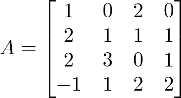

## *8.2 A matriz no R*

As matrizes no R são paralelas com os vetores. Uma de suas características é o fato de não aceitar mais de um tipo de estrutura/classe. Para criar uma matriz, utilizaremos a função `matrix()`.

```r
x = c(1:10) #Criando um vetor

z = matrix(x, nrow = 2, ncol = 5, byrow = F) #Transformando em matriz
p = matrix(x, nrow = 2, ncol = 5, byrow = T) #Criando uma matriz

#Primeira instância: Colocar o "data", o vetor que vai virar matriz
#Segunda instância: Colocar o número de linhas
#Terceira instância: Colocar o número de colunas
#Observação: o número de linhas vezes o número de colunas deve ser igual ao tamanho do meu vetor
#Quarta instância: ordenar por linhas (byrow = T) ou colunas (byrow = F)

z #A matriz
```

```
##      [,1] [,2] [,3] [,4] [,5]
## [1,]    1    3    5    7    9
## [2,]    2    4    6    8   10
```

## *8.3 Manipulando matrizes*

Da mesma forma com os vetores, ao criar uma matriz surgem situações em que precisamos acessar as posições, acessar os valores por uma condição lógica ou precisamos acrescentar valores. Para essas situações, podemos acessar posições utilizando os colchetes `matriz[1]`. Nessa ocasião, o valor que estará dentro dos colchetes se refere à posição do valor. Entretanto, em uma matriz a ordenação de posição inicia da primeira coluna elemento por elemento até a última coluna. De modo didático, vamos partir do exemplo da matriz *p* anterior.

```r
p
```

```
##      [,1] [,2] [,3] [,4] [,5]
## [1,]    1    2    3    4    5
## [2,]    6    7    8    9   10
```

```r
p[5] #Posição
```

```
## [1] 3
```

Observe que a quinta posição corresponde justamente ao número 3. Ou seja, partindo da primeira coluna, a quina posição é o número 3.

Em paralelo com as posições, podemos extrair valores através da sua coordenada. Assim como a ordem de uma matriz é m por n, no colchetes podemos colocar o número da linha e o número da coluna de um elemento. Para isso, colocamos uma vírgula para separar linha de coluna nos colchetes, ou seja, `matriz[número da linha , número da coluna]. Caso nosso objetivo seja extrar apenas uma coluna ou uma linha, apenas não escrevemos **nada** antes ou depois da vírgula, assim indicando o valor que queremos.

```r
p[1,2] #Coordenada
```

```
## [1] 2
```

```r
p[1,] #Retorna a primeira linha
```

```
## [1] 1 2 3 4 5
```

```r
p[,1] #Retorna a primeira coluna
```

```
## [1] 1 6
```

```r
p[-1,] #Tudo menos a primeira linha
```

```
## [1]  6  7  8  9 10
```

Caso queremos atribuir uma condição lógica, podemos utilizar os operadores lógicos. `matriz[matriz > 0]`, nesse exemplo percebemos que estamos extraindo todos os valores da matriz que são maiores que 0.

```r
z[ z > 0 ] #Atribuição lógica
```

```
##  [1]  1  2  3  4  5  6  7  8  9 10
```

Na condição `matriz[matriz > 0]`, estamos dizendo para o script buscar as posições que são verdadeiras `TRUE`.

## *8.4 Atribuindo nomes às colunas e às linhas*

```r
colnames(z) = c("Coluna1", "Coluna2", "Coluna3", "Coluna4", "Coluna5") #Atribuindo nomes as colunas
rownames(z) = c("Linha1", "Linha2") #Atribuindo nomes as linhas
z
```

```
##        Coluna1 Coluna2 Coluna3 Coluna4 Coluna5
## Linha1       1       3       5       7       9
## Linha2       2       4       6       8      10
```

## *8.5 Multiplicando elemento por elemento de matrizes*

```r
p
```

```
##      [,1] [,2] [,3] [,4] [,5]
## [1,]    1    2    3    4    5
## [2,]    6    7    8    9   10
```

```r
z
```

```
##        Coluna1 Coluna2 Coluna3 Coluna4 Coluna5
## Linha1       1       3       5       7       9
## Linha2       2       4       6       8      10
```

```r
p*z #Multiplicação de elementos equivalentes entre as matrizes
```

```
##        Coluna1 Coluna2 Coluna3 Coluna4 Coluna5
## Linha1       1       6      15      28      45
## Linha2      12      28      48      72     100
```

## *8.6 Multiplicação de matrizes no R*

Para multiplicarmos matrizes precisamos ficar atentos que o produto da matriz AB é definido apenas quando o número de colunas em A é igual ao número de linhas em B. Da mesma forma, o produto da matriz BA é definido apenas quando o número de colunas em B é igual ao número de linhas em A.[^3]

```r
a = matrix(x, nrow = 2, ncol = 5, byrow = F)
b = matrix(x, nrow = 5, ncol = 2, byrow = F)

a%*%b #Multiplicação matricial
```

```
##      [,1] [,2]
## [1,]   95  220
## [2,]  110  260
```

## *8.7 Matriz inversa no R*

```r
y = c(1:4)
c = matrix(y, nrow = 2, ncol = 2, byrow = F)
solve(c) #Matriz inversa
```

```
##      [,1] [,2]
## [1,]   -2  1.5
## [2,]    1 -0.5
```

# *9. Dataframes*

## *9.1 O que são Dataframes?*

Por geral, de maneira grossa podemos enxergar um dataframe como uma planilha do Excel. Eles são basicamente tabelas de uma base de dados, sendo cada coluna correspondente à uma variável e cada linha à um registro do banco de dados. Sua aparência é bem similar à de uma matriz, entretanto há uma flexibilidade maior com relação à estrutuda de seus dados. Podemos encontrar em um único dataframe várias classes diferentes. Essa característica torna o mesmo extremamente útil para processos de análises de dados. [^4]

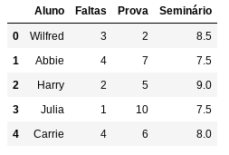

## *9.2 Dataframes no R*

Quando tratamos de dataframes, precisamos da disposição de dados em formatos de vetores. Primordialmente, utilizamos a função `data.frame()` em que passamos vetores como parâmetros.

```r
meux = c("A", "B", "C") #Vetor
meuy = c(1:3) #Vetor

meudata = data.frame(meux, meuy) #Criação do dataframe
```

| meux | meuy |
| --- | --- |
| A | 1 |
| B | 2 |
| C | 3 |

## *9.3 Manipulando Dataframes*

Diante dessa estrutura, seguimos os mesmos parâmetros de slicing (processo de manipulação). Entretanto, vale ressaltar que as posições agora assumem apenas as posições das colunas. Saliento, também, que é possível fazer uma busca colocando o nome do dataframe, cifrão e o nome da coluna `data$coluna`. Usarei frequentemente essa notação, dito que os mesmos retornar um vetor com os valores. Esse processo facilita na análise de dados.

```r
meudata[2] #Posição da coluna (perceba que o data.frame atribui as colunas como posições, e retorna como coluna)
```

```
##   meuy
## 1    1
## 2    2
## 3    3
```

```r
meudata$meuy #Retorna a coluna y em valores
```

```
## [1] 1 2 3
```

```r
meudata[1,2] #Coordenada
```

```
## [1] 1
```

```r
meudata[1,] #Retorna a primeira linha
```

```
##   meux meuy
## 1    A    1
```

```r
meudata[,1] #Retorna a primeira coluna
```

```
## [1] A B C
## Levels: A B C
```

```r
meudata[-1] #Tudo menos a primeira posição (note que a primeira posição é a primeira coluna INTEIRA)
```

```
##   meuy
## 1    1
## 2    2
## 3    3
```

```r
meudata[-1,] #Tudo menos a primeira linha
```

```
##   meux meuy
## 2    B    2
## 3    C    3
```

### *9.3.1 Extraindo uma coluna*

```r
g = meudata$meuy #Atribuindo os valores da coluna a uma variável
g*2 #Multiplicando todos os valores por 2
```

```
## [1] 2 4 6
```

```r
g[g%%2 == 1] #Atribuição lógica
```

```
## [1] 1 3
```

### *9.3.2 Nomeando as colunas*

```r
colnames(meudata) = c("Coluna1", "Coluna2") #Atribuindo nomes as colunas
```

| Coluna1 | Coluna2 |
| --- | --- |
| A | 1 |
| B | 2 |
| C | 3 |

### *9.3.3 Adicionando colunas*

```r
meudata[3] = c(4,5,6) #Adicionando uma nova coluna ao dataframe
```

| Coluna1 | Coluna2 | V3 |
| --- | --- | --- |
| A | 1 | 4 |
| B | 2 | 5 |
| C | 3 | 6 |

## *9.4 Estudando o Dataframe*

Geralmente, quando temos um dataset em mãos, procuramos um resumo geral de suas características. Essas informações podem ser elucidadas utilizando a função `str()`, ou a função `glimpse()`, do pacote **dplyr**. De forma mais clara, irei utilizar as duas funções no *meudata*.

```r
str(meudata)
```

```
## 'data.frame':    3 obs. of  3 variables:
##  $ Coluna1: Factor w/ 3 levels "A","B","C": 1 2 3
##  $ Coluna2: int  1 2 3
##  $ V3     : num  4 5 6
```

```r
if(!require(dplyr)) install.packages("dplyr")
dplyr::glimpse(meudata)
```

```
## Rows: 3
## Columns: 3
## $ Coluna1 <fct> A, B, C
## $ Coluna2 <int> 1, 2, 3
## $ V3      <dbl> 4, 5, 6
```

## *9.5 Salvando o Dataframe*

Quando criamos um dataframe, fazemos suas análises, processamos os dados e queremos salvar esses resultados em um csv. Para isso, usamos a função `write.table(nome_do_data, row.names = FALSE, file = "nome_do_data.csv", sep=";")`. Observe que neste comando estamos definindo: o nome do dataframe, **não queremos nomes nas linhas** (esse parâmetros é importante, para que o seu cabeçalho não fique desorganizado), o nome do arquivo e sua extensão (csv) e também o separador. O arquivo será salvo no diretório atual (irei comentar sobre ele nos próximos tópicos).

```r
write.table(meudata, row.names = FALSE, file="meudataa.csv", sep=";")
```

# *10. Importando Datasets*

Ao invés de criar um dataframe, você precisa importar uma tabela já pronta? Sem preocupações! No R conseguimos importar datasets de vários lugares, como o SQL, Excel, aquivos txt, entre outros. Nesse caso irei focar nos 3 principais.

## *10.1 O diretório*

É importante salientar que, quando importamos um dataset diretamente pelo código necessitamos da presença do arquivo em nosso diretório. Caso você não saiba seu diretório atual, basta executar o comando `getwd()`. Para alterar o diretório, utilizamos o comando `setwd()`, sendo que o parâmetro é o camanho do diretório onde está seu arquivo. Se você está utilizando o RStudio, é possível realizar esse processo sem o código. Basta ir em `Session>Set Working Directory>Choose Directory`.

## *10.2 Carregando o pacote “readr”*

Por fins de facilitar o processo, iremos utilizar o pacote `readr` do R. É um pacote nativo, basta carregá-lo na sua sessão para sua utilização. Carregamos ele com a função `library(readr)`

```r
library(readr)
```

## *10.3 Importando dados do Excel*

```r
read_excel("nome_do_arquivo.xlsx")
```

De uma forma mais prática, no RStudio temos na seção “ambiente” a coluna “Environment” (ambiente). Nela, há a opção `Import Dataset`. Ao clicar em *From Execel*, selecionamos o arquivo desejado em `Browse` e delimitamos os parâmetros encontrados no canto inferior esquerdo de acordo com o que necessiamos.

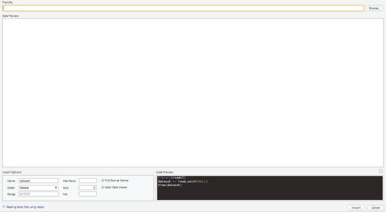

Entretanto, há outra forma de importar dados do Excel. Podemos selecionar os dados na planilha, copiá-los e utilizar o comando `read.table()` para “colar” os dados em forma de data.frame.

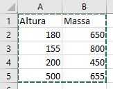

```r
x = read.table("clipboard", h = T)
```

## *10.4 Importando dados CSV*

Muitos datasets estão dispostos neste formato. Para fazer a leitura, iremos utilizar o comando `read_csv()` do pacote `readr`.

```r
read_csv("nome_do_arquibo.csv")
```

Da mesma forma como feita no passo anterior, podemos utilizar a seção **Enviroment** para realizar o nosso *import*. Ao clicar em `Import Dataset`, clicaremos em *From Text (readr)*. O mesmo que fizemos para o Excel, iremos fazer com o CSV. Em `Browse` selecionamos o arquivo e no canto inferior esquerdo encontramos as características do nosso arquivo. É importante escolher corretamente se há um cabeçalho, se o separador (vírgula, ponto e vírgula, tabulação…) está correto! Leia todos os fatores antes de importar o arquivo. O nome da variável do dataset irá ser o mesmo do nome do arquivo. **Para evitar conflitos, EVITE usar acentos e pontuações nos nomes dos arquivos.**

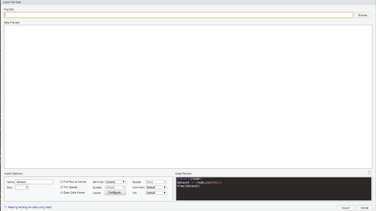

## *10.5 Importando dados TXT*

Para fazer a leitura, iremos utilizar o comando `read.delim(")` do pacote `readr`.

```r
read_delim("nome_do_arquibo.txt")
```

Podemos também utilizar a seção **Enviroment** para realizar o nosso *import*. Ao clicar em `Import Dataset`, clicaremos em *From Text (base)*. Imediatamente selecionamos o arquivo e encontraremos as características do nosso arquivo. É importante escolher corretamente se há um cabeçalho, se o separador (vírgula, ponto e vírgula, tabulação…) está correto! Leia todos os fatores antes de importar o arquivo. O nome da variável do dataset pode ser alterado na aba `Name`. **Para evitar conflitos, EVITE usar acentos e pontuações nos nomes dos arquivos.**

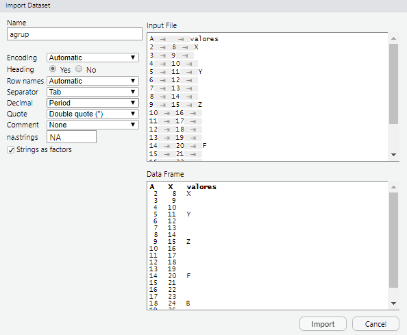

# *11 Estruturas lógicas*

Em um processo de análise, há momentos em que necessitamos de uma lógica para continuar o progresso. Essas lógicas podem ser atribuídas às estruturas de repetição ou às estruturas condicionais.

## *11.1 Estruturas condicionais (IF)*

```r
number = 5 #Atribuindo um valor a minha variável

if(number > 0){ #"Se", o que está entre os parênteses for verdadeiro
  print("O número é positivo.") #Faça o que está dentro das {}
}else{ #Caso contrário
  print("O número é negativo.") #Faça o que está dentro das {}
}
```

```
## [1] "O número é positivo."
```

Podemos reescrever o códico acima em apenas uma linha. A primeira instância é a condição, a segunda é o retorno *se verdadeiro* e a terceita o retorno *se falso*.

```r
ifelse(number>0, "Positivo", "Negativo") #Estrutura lógica em uma linha
```

```
## [1] "Positivo"
```

Há casos em que necessitamos de mais condições dentro de um laço. Diante disso, utilizamos o `else if` ao invés de somente `else`.

```r
if(number == 5){
  print("O número é igual a 5")
}else if(number > 5){
  print("O número é maior que 5")
}else if(number < 5){
  print("O número é menor que 5")
}
```

```
## [1] "O número é igual a 5"
```

## *11.2 Estruturas de repetição (FOR)*

```r
z = c(1:10) #z é um vetor de 1 a 10

for(i in z){ #Perceba: o "i" irá percorrer todos os elementos de z
  print(i)
}
```

```
## [1] 1
## [1] 2
## [1] 3
## [1] 4
## [1] 5
## [1] 6
## [1] 7
## [1] 8
## [1] 9
## [1] 10
```

## *11.3 Estruturas de repetição (WHILE)*

```r
a = 1 #"a" é uma variável que recebe o valor 1

while(a < 10){ #Enquanto o "a" for menor que 10, faça o que está dentro das {}
  print(a)
  a = a + 1 #Perceba que, após a o script precisamos alterar o valor de "a" para evitar um loop infinito
}
```

```
## [1] 1
## [1] 2
## [1] 3
## [1] 4
## [1] 5
## [1] 6
## [1] 7
## [1] 8
## [1] 9
```